# Final Report

Final Project  
Data Science 1 with R (STAT 301-1)

Author

Elsa Steen Koppell

Published

March 4, 2025

**Github Repo Link**

[Steen Koppell: Final Project GitHub Repository](https://github.com/steenkoppell/baseball.git)

## Introduction

Baseball is America’s pastime. While scouts once looked for confidence and pretty girlfriends[^1], advanced statistics are now the name of the game. I find the current wave of advanced metrics in sports extremely fascinating. Baseball analysis was radically changed by the introduction and proliferation of Sabermetrics, which attempts to quantify nearly every aspect of player performance. I am drawn to analytics, in and beyond baseball. This project is an opportunity to further my interest and gain practical experience.

<sup>1</sup> *Moneyball* (2011) reference

<sup>2</sup> My brother is a left-handed baseball player. I’d like to formally disclose my existing bias against southpaws.

I approach this dataset with a number of initial questions. Are lefty hitters really all that?[^2] What makes a fastball “fast”? Can you tell a player is good by looking at his spray charts? I’ve witnessed a number of evaluation techniques, from David Ortiz and Alex Rodriguez arguing at the desk to advanced analytical articles on Baseball Savant to my father calling Aaron Judge a host of (appropriate?) names during his postseason slump. I look to this project for a chance to try it out myself. I’ve got questions and I’m on the hunt for some answers.

The data are pitch-level data for 701,557 pitches thrown Major League Baseball games between April 2, 2024 and October 30, 2024. The data comes from the Baseball Savant website. I found it via the Connecticut Sports Analytics Data Challenge (CSADC), which provides the data on its website for the 2025 iteration of the challenge. Brian Macdonald, a statistics professor at Yale, the host university of the symposium the challenge is part of, uploaded the data to a OneDrive folder.

Additionally, I used a list of switch hitters during the 2024 MLB season, taken from the [FANGRAPHS](https://fangraphs.com) website. I am a paying member of FANGRAPHS, which allows me to export custom .csv files from their site. I defined my search parameters and exported a csv which I then put into the /data folder of my final project directory.

## Data Overview & Quality

`raw_statcast_data` has 113 variables. See Table 1 for a breakdown of type. There are 701,557 observations, each of which represents a single pitch. The data for each pitch is extensive. The categorical variables deal with player information (hitters, pitchers, runners, fielders), pitch type, and outcome. The numerical variables cover the metrics: release speed, launch angle, horizontal movement, etc.

Table 1: Data types, `raw_statcast_data`

[figure not shown]

The original raw data were already decently clean. Due to the sheer size of the data and the existence of numerous confounding variables, the biggest challenges were parsing through the relevant data and identifying reasonable goals for exploratory analysis.

I did a large portion of the data cleaning as I went along. Because I was not initially sure exactly which explorations I wanted to pursue, I was hesitant to remove any variables that weren’t almost or entirely missing. I did go through certain variables, like pitch type, and identify values that only applied to a few of the 701,557 observations. For example, 51 pitches were listed as pitch-outs, i.e. when the pitcher intentionally throws the ball away. That was not relevant to any of my analyses and as they were atypical pitches, I did not want to skew the data, so I removed them. The logical variables alluded to in Table 1 were entirely missing, so that was not a huge issue. At the bottom of the `data_cleanup.R` file, I added the code that I used to create my more targeted dataset. It is in the creation of the these datasets that the complexity of the data cleaning comes from.

Within the smaller datasets, I modified existing data types and created new variables. For example, none of the categorical variables were factors, and I consciously left them as such in the main `statcast_data` dataset. However, in certain analyses, I converted variables like `pitch_type` into factors and reordered them, to suit the particular focus. In my spray charts in both main analyses, I had to modify `hc_x` and `hc_x` to fit them onto a baseball diamond. In `plate_appearance_data`, I used pivots to construct a more compact dataset with which pitching strategy could be examined more pointedly.

## Exploratory Data Analysis (EDA)

### Focus 1: The Platoon Advantage

#### Background

In baseball, it is widely accepted that batters perform better against pitchers of the opposite hand, i.e. right-handed hitters get relatively more hits against left-handed pitchers than right-handed pitchers and vice versa. Similar to the general population, right-handers are much more numerous in baseball. See Table 2 for the breakdown of pitchers and hitters by handedness. Left-handed hitters are at a significant advantage if popular sentiment is true. Thus they’ve become a prized commodity, with right-handed players learning to hit left-handed just to give themselves more of a shot.

Table 2: Handedness

[figure not shown]

#### Evaluating the Advantage

I want to explore the legitimacy of these claims in my dataset. First, it’s clear that the platoon advantage is highly sought after by 2024 MLB players. Figure 1 represents the number of players who hit right-handed or left-handed given the handedness of the pitcher. Without the platoon split strategy, we could expect that the proportion of right- and left-handed batters should be quite similar between right- and left-handed pitchers. In fact, we see this is not the case at all.

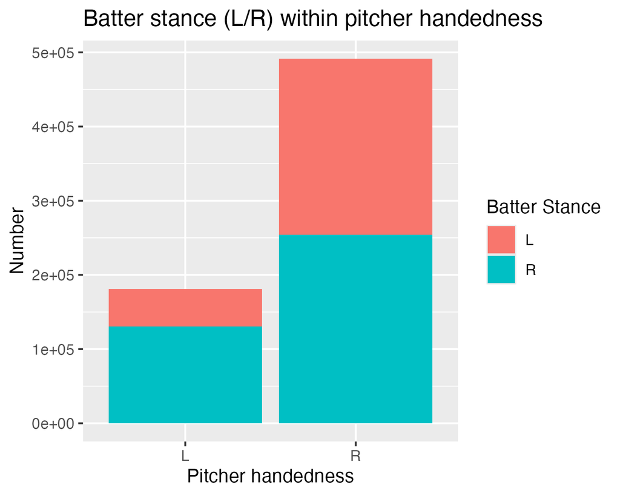

Figure 1: Stance vs. handedness

Against left-handed pitchers, there is a clear majority of right-handed pitchers. But against right-handed pitchers, the balance is very split, the number of right-handed hitters is only slightly greater than the number of left-handed hitters. In fact, this phenomenon helps to explain the data in Table 2. The numbers of left-handed pitchers (220) and batters (221) are almost exactly the same, but there are 261 (1.7 times) more right-handed pitchers (625) than right-handed batters (364). But by far the clearest evidence for the degree to which baseball strategists believe the platoon advantage is real is in switch hitter behavior. Switch hitters are comfortable hitting both left-handed and right-handed, meaning they can react to the handedness of the individual pitcher and change their stance based on it. There were 77 switch hitters present in the dataset. Figure 2 is identical to Figure 1 except it only contains data from those 77 switch hitters. How do they behave?

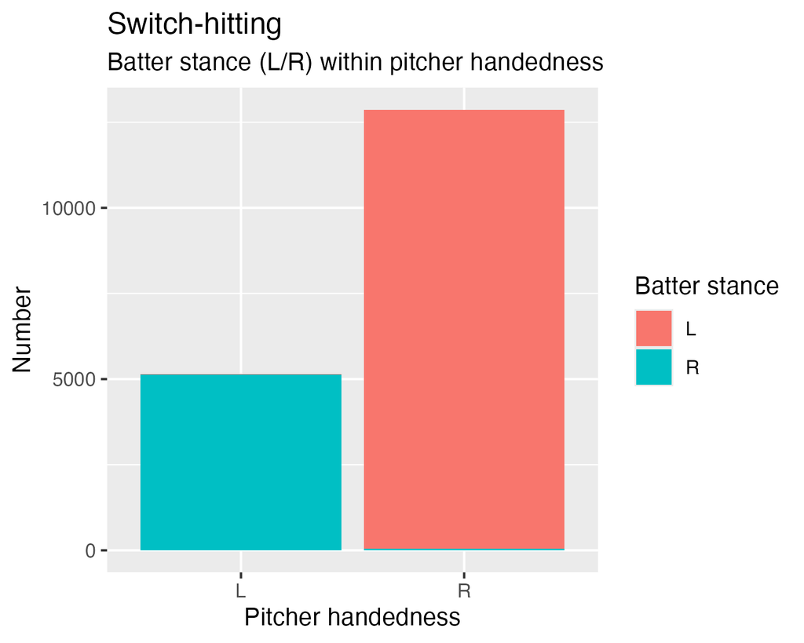

Figure 2: Switch-hitter behavior

With only a few exceptions, switch hitters hit in the opposite stance as the pitcher’s handedness. They **chose** to do this because of the platoon advantage. Without it, this behavior makes no sense. So how strong is the advantage to provoke such a great deviation from expected behavior?

There is statistical evidence to support the existence of platoon advantages, but curiously, when I compared outcomes of different pitcher/batter handedness match-ups, it wasn’t clear. I assigned each observation to one of four categories, based on the combination of batter and hitter (BLPL, BLPR, BRPL, BRPR). Then, I compared their outcomes in Figure 3, where you can see the proportion of pitches by the handedness splits, grouped by the outcome[^3] of the pitch.

<sup>3</sup> Note: I removed a few outcomes, e.g. hit-by-pitch, that were either very rare or not relevant to the research question.

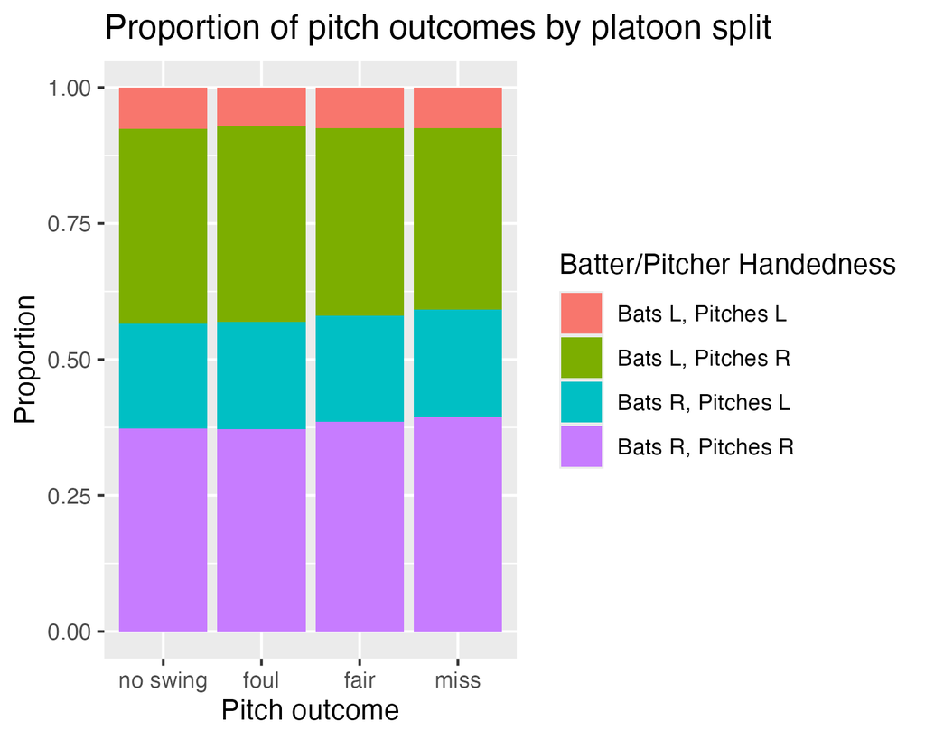

Figure 3: Platoon split effect on outcome

There doesn’t seem to be the huge effect people say, at least in the 2024 data. Figure 4 combines the possible splits into two categories (hands match, hands do not match). Even then, there’s no clear pattern.

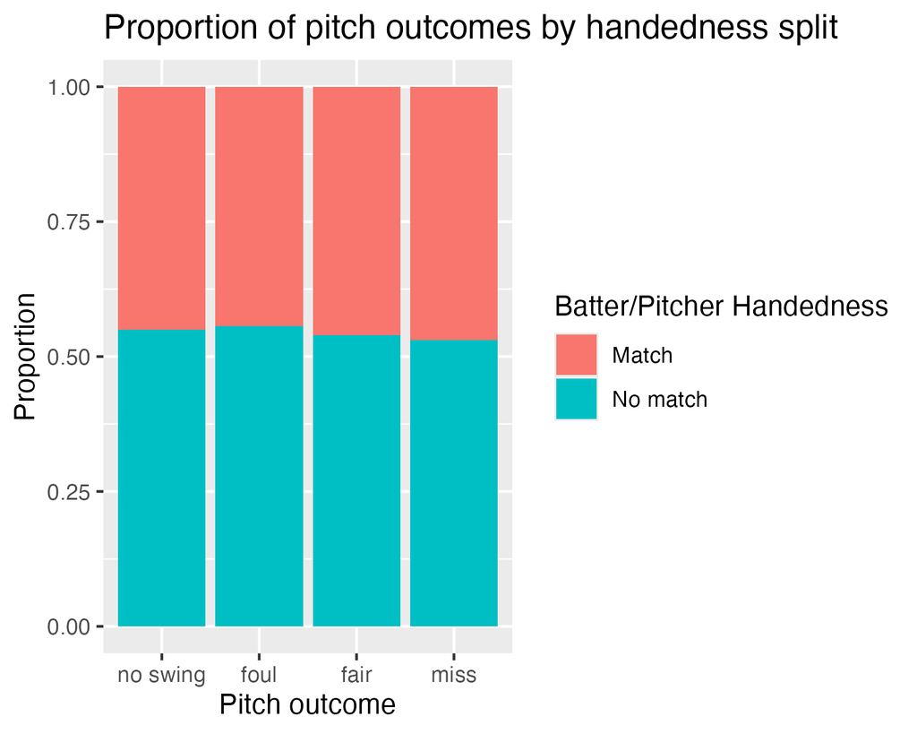

Figure 4: Split outcomes simplified

#### Spray Charts

Let’s see how the spray charts of left- and right-handed hitters compare. To make these, I used a combination of `geom_baseball()` in the `sportyR` package and `geom_point()`. I plotted the location of each batted ball (using `hc_x` and `hc_y`) and adjusted the coordinates so they would fit on an image of a baseball diamond.

First, I want to compare the spray charts of non-switch hitters. I used four players for this, all of whom are among the 10 players in the `statcast_data` dataset with the most plate appearances. I ascertained this using my created `plate_appearance_data` dataset. In Figure 5, we see the spray charts of Gunnar Henderson, Luis Arráez, Anthony Volpe, and Marcus Semien.[^4]

<sup>4</sup> “Match” encompasses BLPL and BRPR. “No match” encompasses BLPR and BRPL.

**Note**

To compare left- and right-handed hitters, I chose two of each:  
Gunnar Henderson and Luis Arráez hit left-handed.  
Anthony Volpe and Marcus Semien hit right-handed.  
Note that all four of these players throw right-handed.

**Figure 5: Spray Charts of Non-Switch Hitters**

**Marcus Semien**

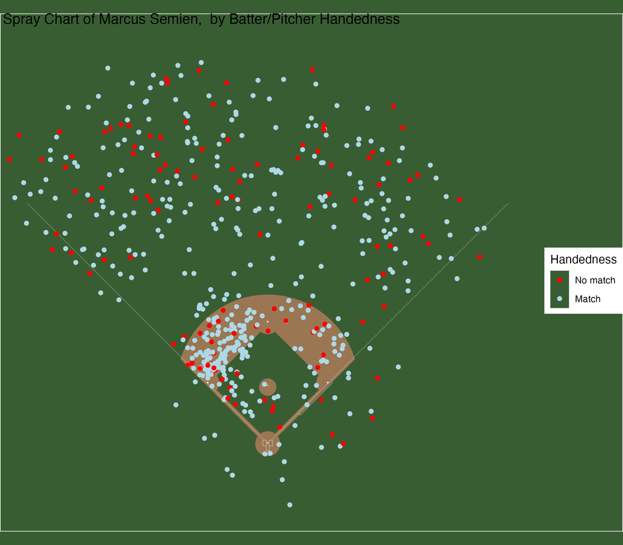

Hits right, bats right.

**Anthony Volpe**

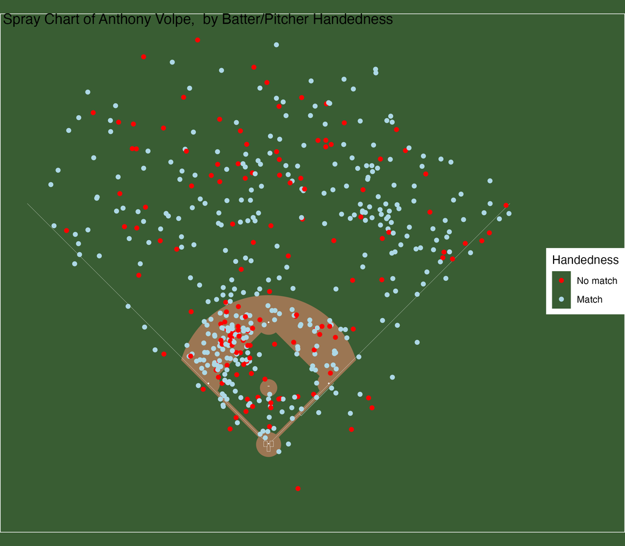

Hits right, bats right.

**Luis Arráez**

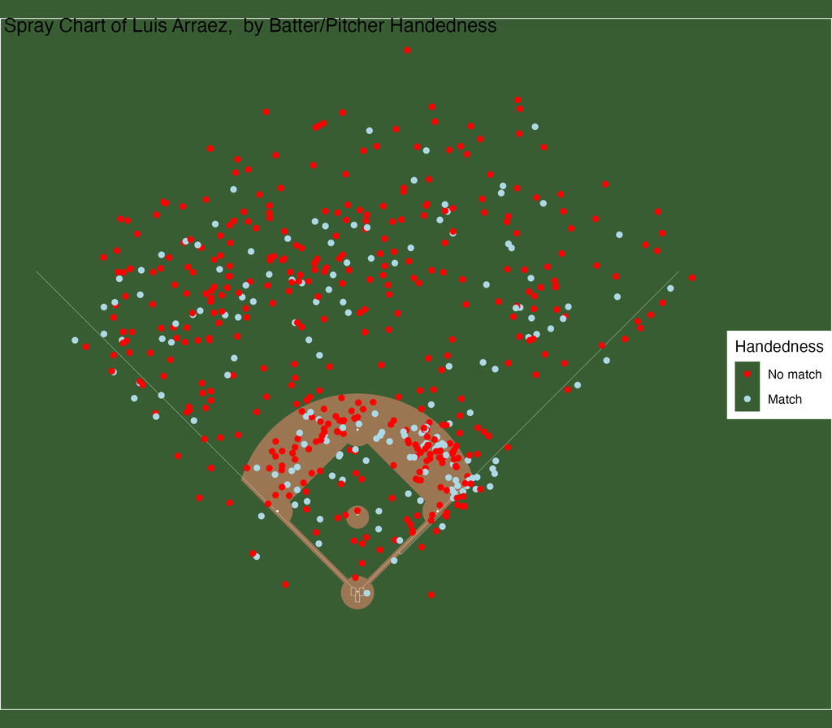

Hits left, bats right.

**Gunnar Henderson**

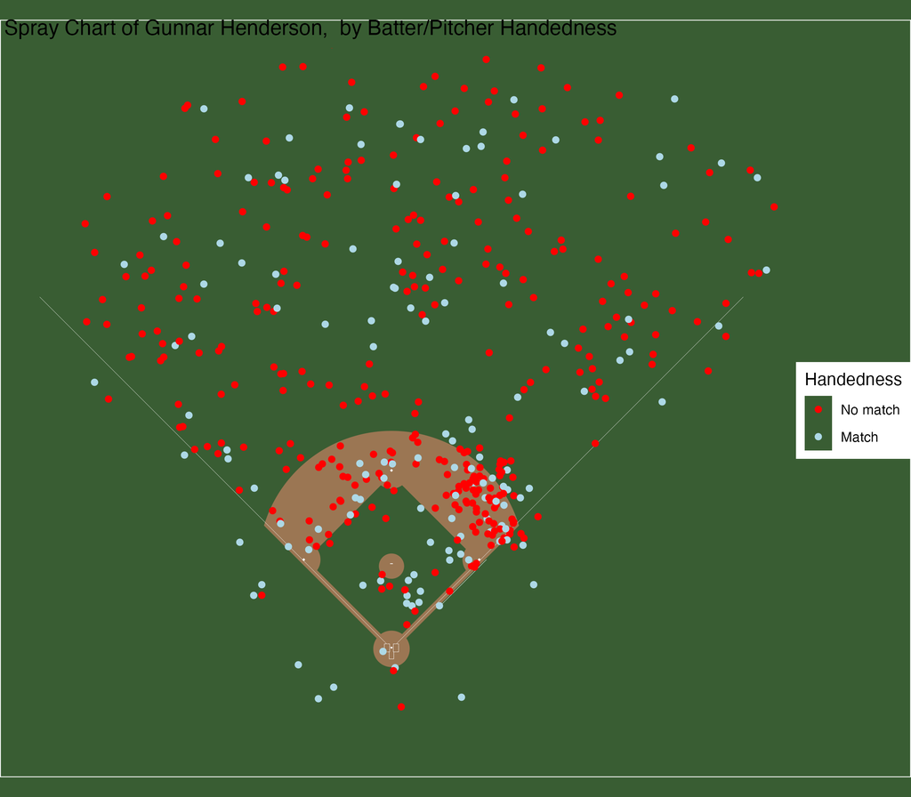

Hits left, bats right.

There are multiple takeaways from these spray charts. The left-handed hitters hit many more balls into play off of right-handed pitchers, as expected. The right-handed batters require a bit more thought. They hit more balls into play off of right-handed pitchers, which seems like a violation of the principle. However, there are simply more right-handed pitchers to hit off of. What would really illustrate the phenomenon are the spray charts of batted balls that were not outs, e.g., singles, doubles, triples, and home runs. Figure 6 shows just that.

**Figure 6: Spray Charts of Safe Hits by Non-Switch Hitters**

**Marcus Semien**

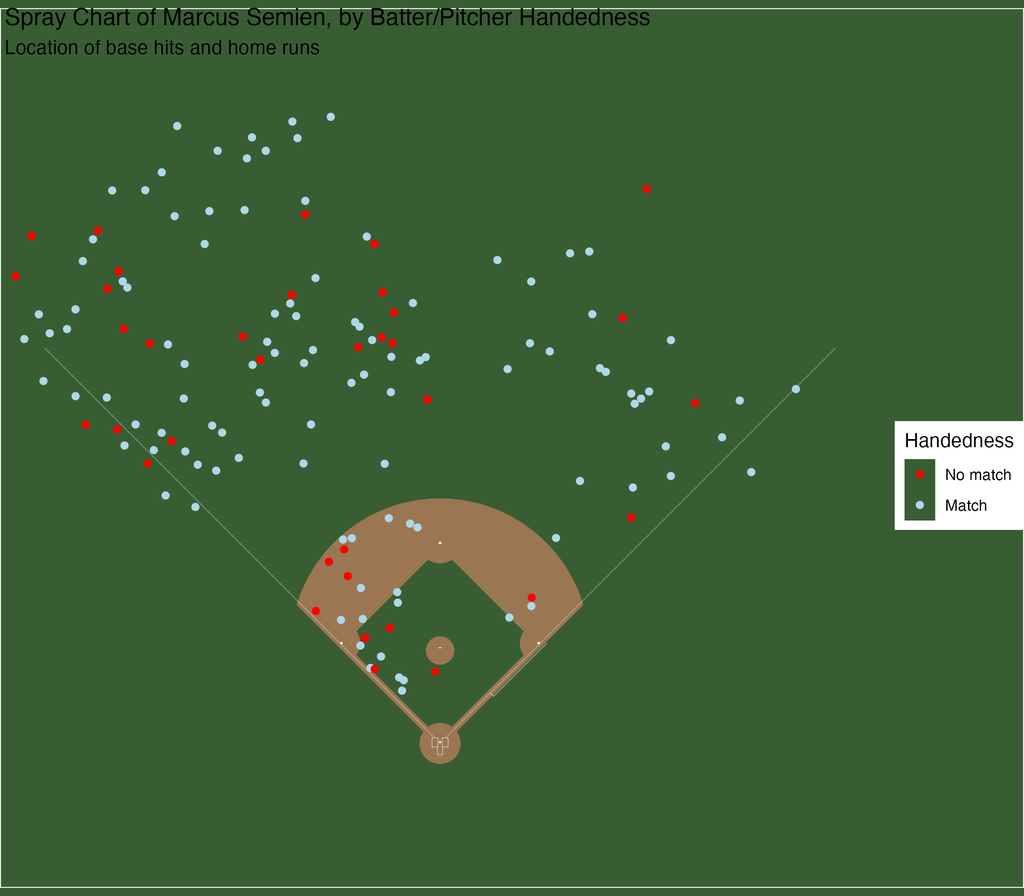

Hits right, bats right.

**Anthony Volpe**

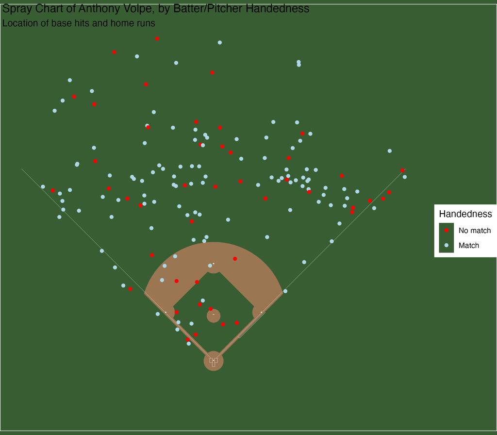

Hits right, bats right.

**Luis Arráez**

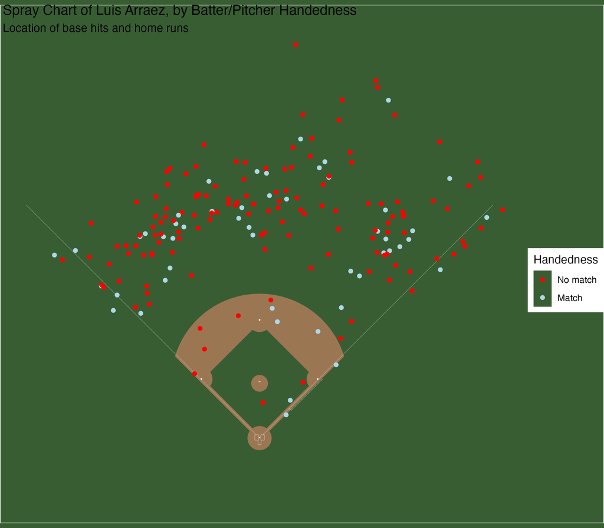

Hits left, bats right.

**Gunnar Henderson**

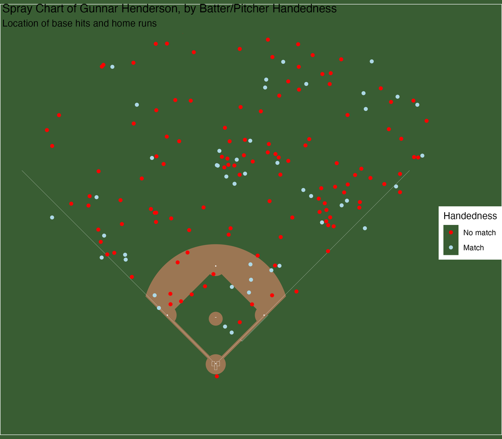

Hits left, bats right.

Finally, we will look at the spray charts of switch hitters. As discovered in Figure 2, switch hitters overwhelming (>99% of the time) opt to hit in the stance opposite the pitcher’s handedness. Below (in Figure 7), I examine the spray charts of four switch hitters: Elly De La Cruz, Ian Happ, Francisco Lindor, and Jurickson Profar. Unlike with non-switch hitters, there is no need to clarify whether the batter/pitcher handedness matches. Instead, the points are differentiated by pitcher (and thus batter) handedness.

**Figure 7: Spray Charts of Switch Hitters**

**Elly De La Cruz**

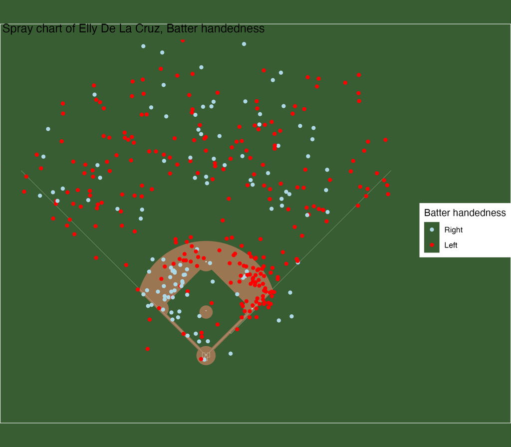

Switch hits, throws right.

**Ian Happ**

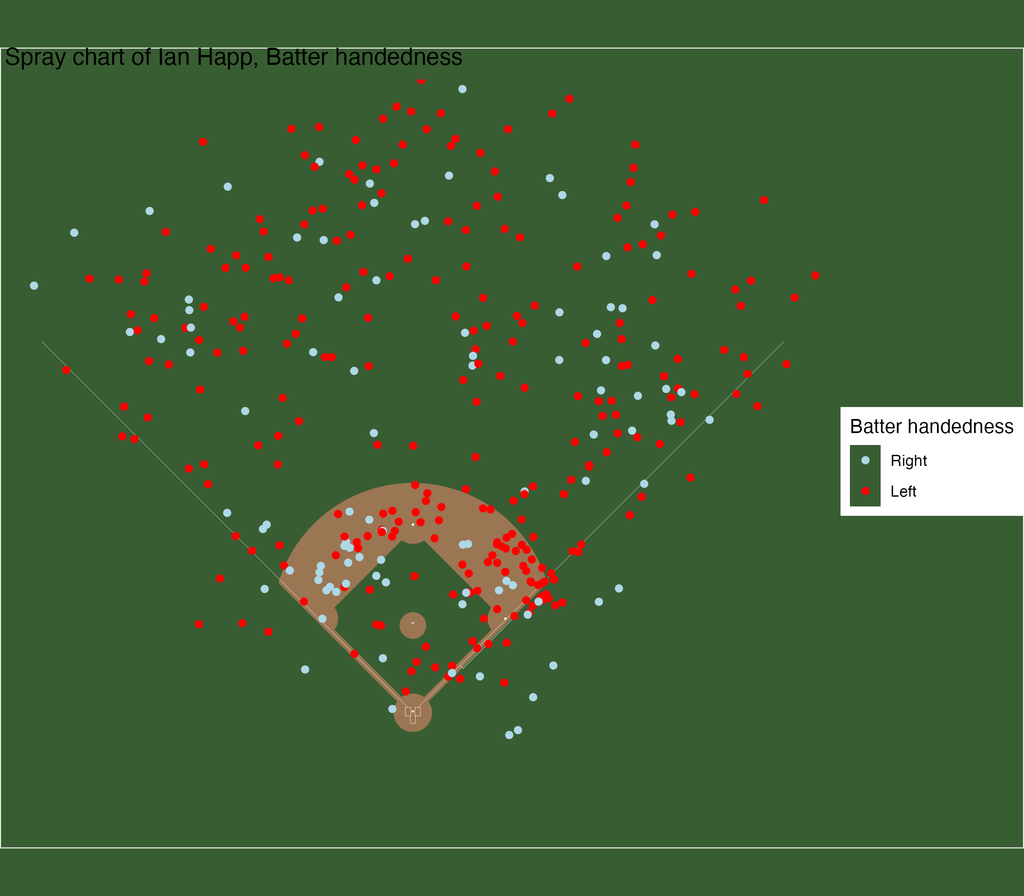

Switch hits, throws right.

**Francisco Lindor**

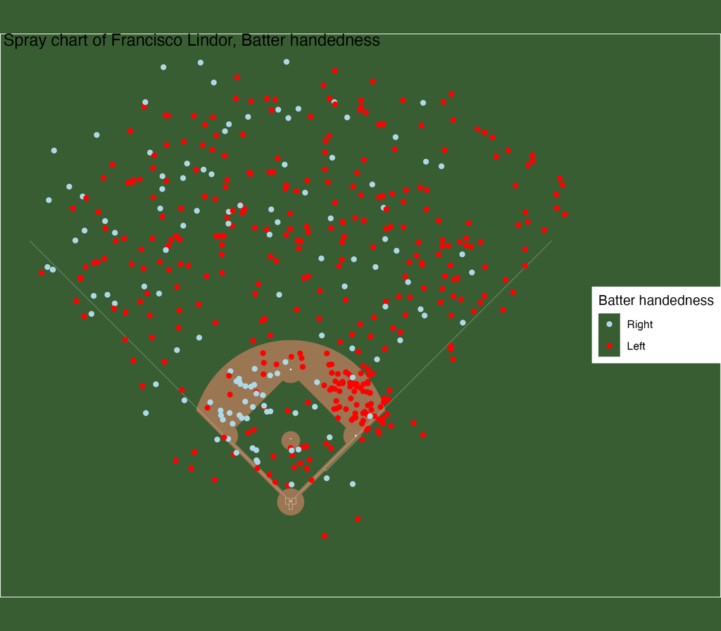

Switch hits, throws right.

**Jurickson Profar**

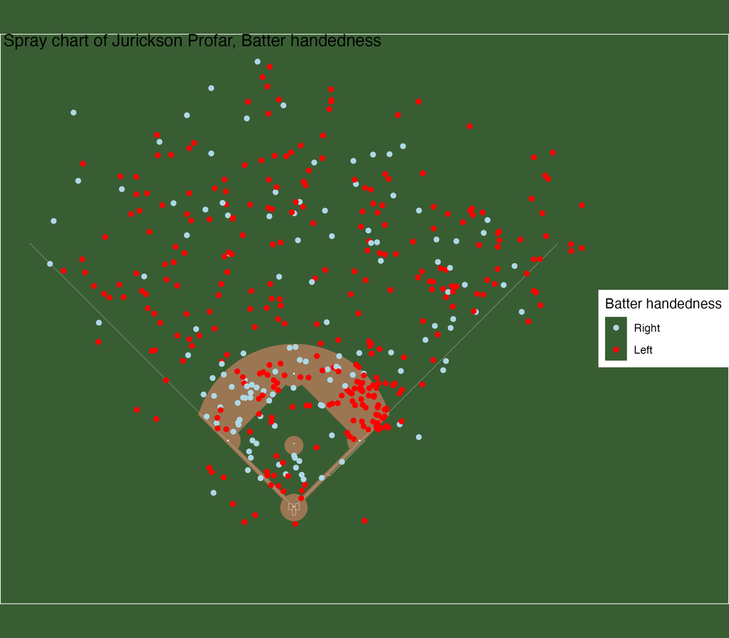

Switch hits, throws right.

Notice that these spray charts look much different than those of players who only bat from one side. They seem to have greater ability to reach different parts of the field. Luis Arráez pounded balls to the left outfield; Anthony Volpe hit more to right field. All four of these switch hitters have pretty even coverage across the outfield. Sprays like Arráez and Volpe’s make sense with a cursory knowledge of baseball mechanics.

Finally, let’s look at the spray charts of the same switch hitters, but only include their safe hits.

**Figure 8: Spray Charts of Safe Hits by Switch Hitters**

**Elly De La Cruz**

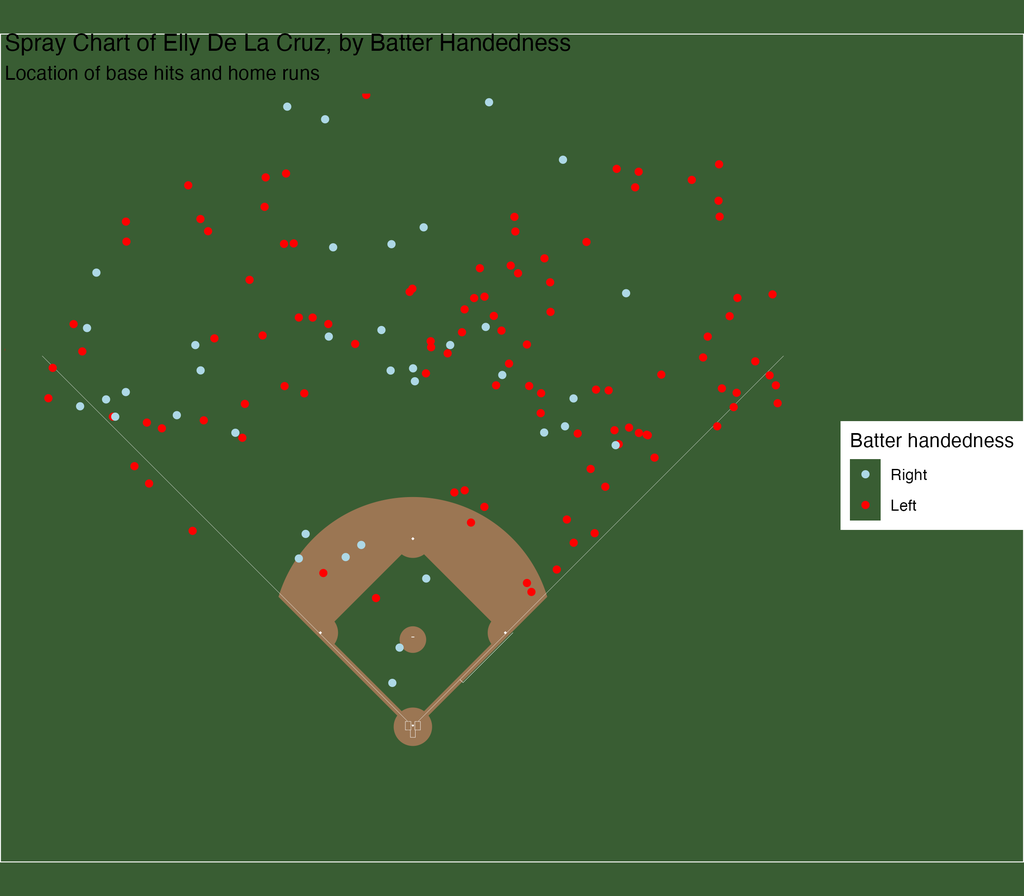

Switch hits, throws right.

**Ian Happ**

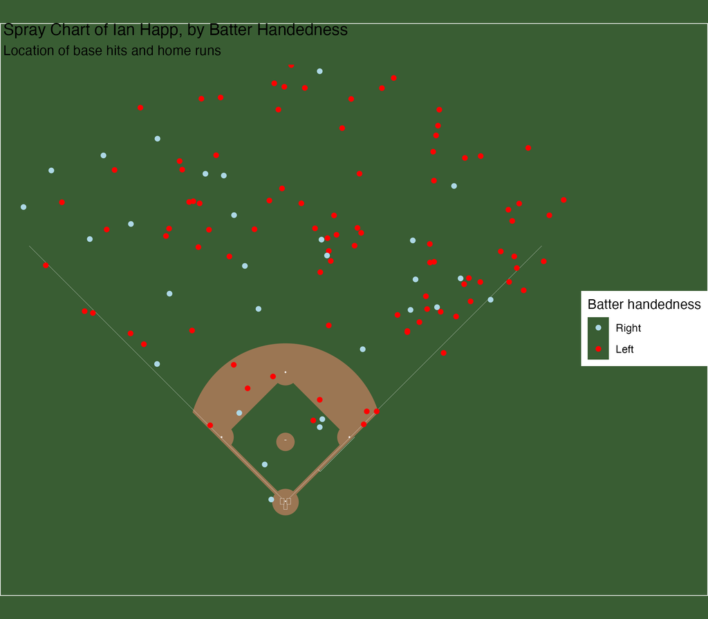

Switch hits, throws right.

**Francisco Lindor**

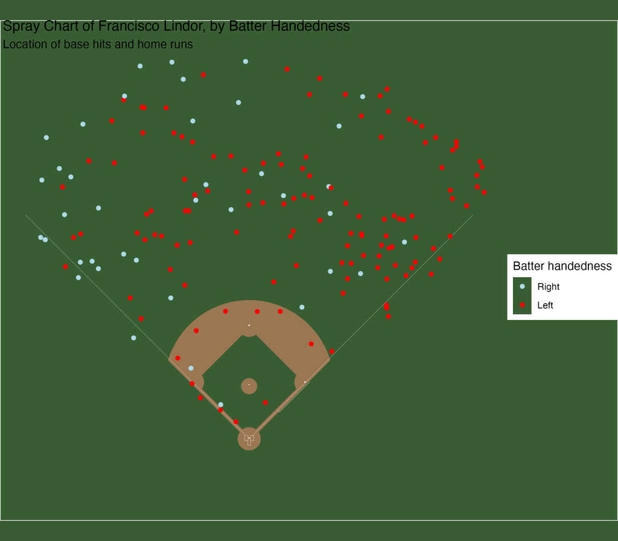

Switch hits, throws right.

**Jurickson Profar**

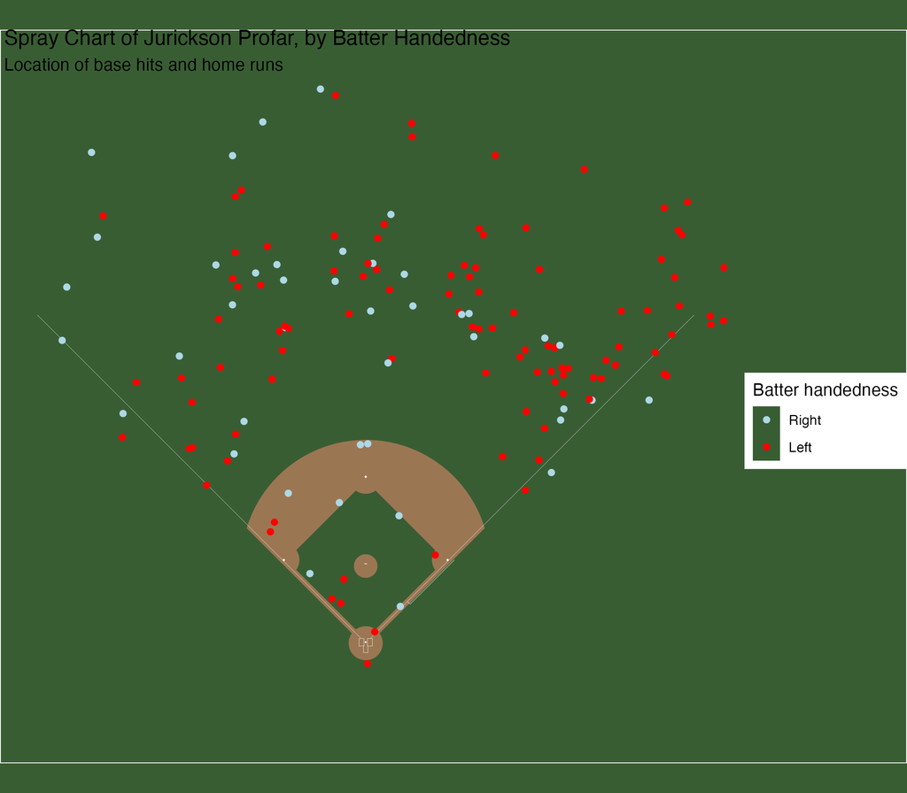

Switch hits, throws right.

#### Final Thoughts

Before I end this section, I want to emphasize just how sacrosanct the practice of platoon-ing is in baseball. From Little League, talented right-handed position players are encouraged to begin hitting left-handed to cultivate the advantage. It is why left-handed hitters are so overrepresented in the MLB, as seen in Figure 1. There are numerous players who throw right-handed and hit either left-handed or switch. All four of the switch hitters in Figure 7 are natural righties, in addition to the left-handed (and right-handed) hitters in Figure 5. I was only able to find one active switch hitter who is listed as throwing left-handed: Brandon Hughes, a reliever who spent the 2024 season with Diamondbacks. Hughes has not had an at-bat since 2022. Pitchers are more likely to throw left-handed and hit right-handed: Nestor Cortes, Framber Valdez, and recently retired Madison Bumgarner are all examples. It is *extremely* rare among position players: only Chas McCormick and Jake Meyers (both of the Houston Astros) throw left and hit right. In 2024, they faced 946 and 1762 pitches, respectively.

Handedness is also relevant in fielding, though not because of the platoon advantage. The orientation of a baseball diamond makes it incredibly difficult for left-handed fielders to succeed in positions like second base, shortstop, and third base, where right-handed fielders can throw a ball to first without turning their entire body around. Infielders (excluding first base) have been right-handed since the nineteenth century. My younger brother, a diehard Jeter, experienced this very phenomenon when his Little League coaches steered him from shortstop to the mound and first base. Even in the 9-10 age division (and younger), handedness reigns supreme.

### Focus 2: Pitch characteristics

For my second focus, I want to examine the specific characteristics of pitches, namely speed, type, and location, and see how they interact, with each other and with the outcome of each pitch/plate appearance.

#### Pitch Speed

Let’s first talk about pitch speed. From `baseballr::mlb_pitch_types()`, I got a list of pitch types along with their associated code. I filtered out the codes that are not present in `statcast_data` (post-tidying) and used a FANGRAPHS article to classify each pitch as either a fastball or off-speed pitch, seen in Table 3.

Table 3: Pitch types and speeds

[figure not shown]

While there are variations between pitches in either category, particularly among off-speed pitches, I felt that making this adjustment allowed for more far-reaching exploration. I first wanted to answer the question of what it means to be off-speed. In Figure 9, I compare the median speeds of each of the pitches.

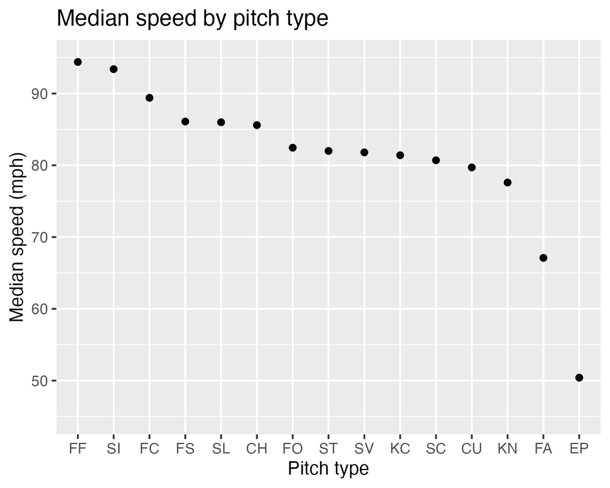

Figure 9: Median speed

This mostly makes sense, except for one pitch, FA or “Fastball”. I was initially confused by this, until I looked at the pitcher IDs for each of these FA pitches. They are the IDs of position players. I concluded that these pitches are the result of position players coming in to pitch in blowout games or other situations where it is not worth it to tire an actual pitcher’s arm. Because I’m interested in the interactions of batters with actual pitchers, I filtered out these instances. With this change, the graph shows the decreased speed of off-speed pitches, no exceptions.

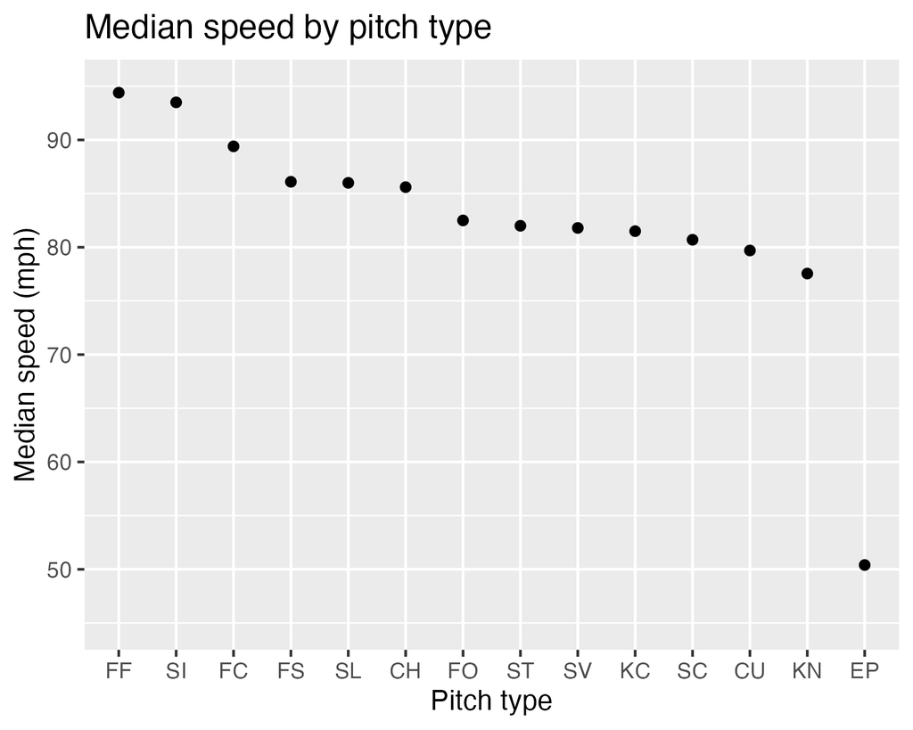

Figure 10: Median speed, no position players

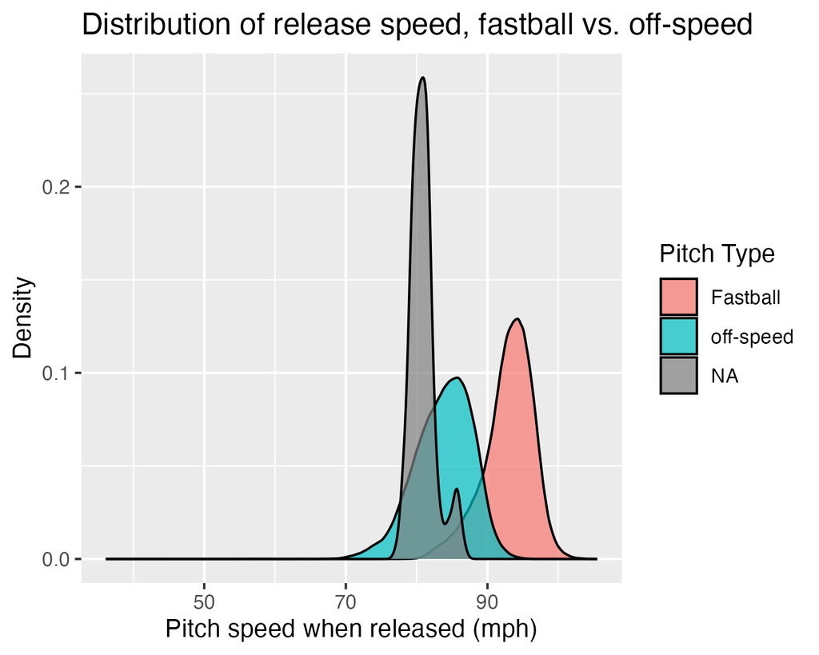

Figure 11: Pitch speed by class

As the name suggests, fastballs are much faster than off-pseed pitches. It looks to be a difference of 10 mph (approximately) on average. Interestingly, the spread of the off-speed pitches is bigger. Perhaps this is because of the variety of off-speed pitches, which include curveballs, changeups, forkballs, slurves, etc. Off-speed pitches typically have greater movement than fastballs. That movement contributes to the reduced speed. Fastballs are less variable; they are fast. Cutters and sinkers (FC and SI, respectively) are two fastballs with movement. Cutters break (“cut”) towards the pitcher’s glove side and sinkers move downward (“sink”). Their movement is largely standard, unlike a curveball, which depends on release angle, grip, etc. Figure 12 shows the horizontal and vertical movement of fastballs and off-speed pitches.

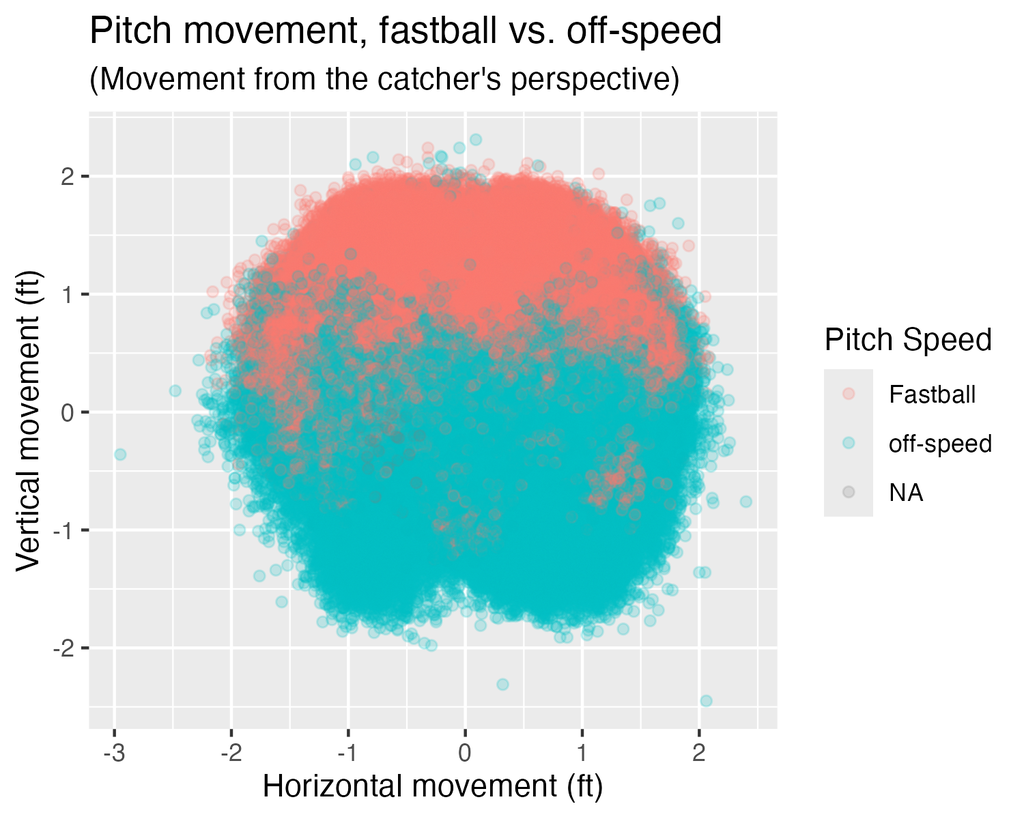

Figure 12: Movement by speed class

Notice that off-speed pitches tend to fall whereas fastballs drop either a bit or rise. Perhaps this is because gravity has more time to act on an off-speed pitch, or because off-speed pitches break more on average. It’s interesting that there is a distinct dimple in the teal mass of off-speed pitches around the marker for zero horizontal movement, once again showing that off-speed pitches *move*.

#### Plate Appearances

Next, I want to analyze pitch type in the context of a plate appearance. To do this, I created a dataset `plate_appearance_data` using `pivot_wider()` which collects each pitch in a plate appearance into one observation. The longest plate appearance in this data was 14 pitches long. Figure 13 shows this is not the norm. It shows the distribution of plate appearances by the number of pitches.

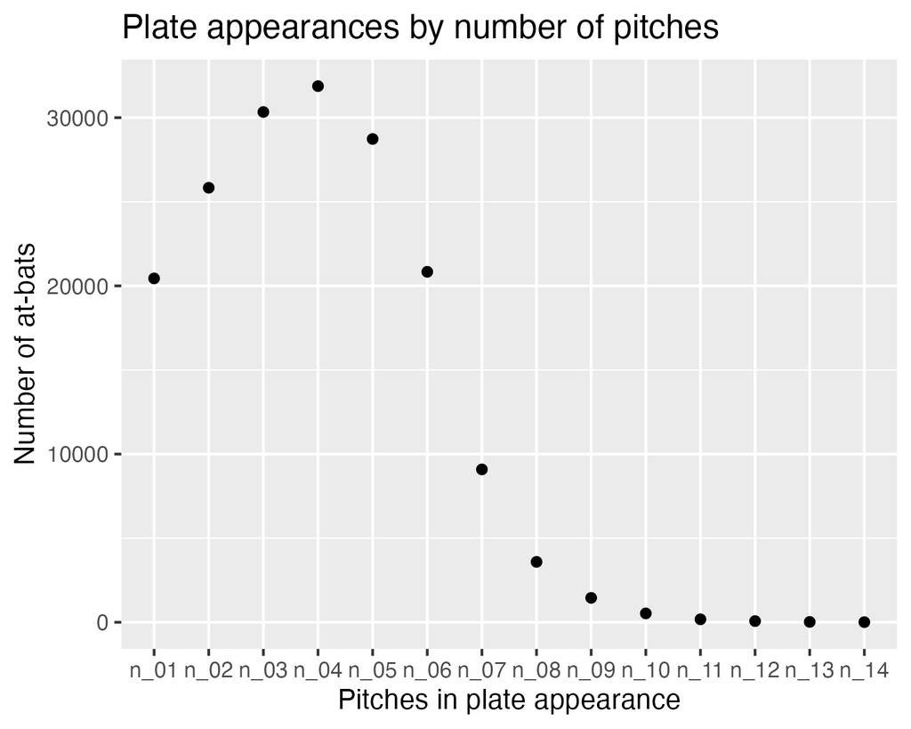

Figure 13: Pitches per plate appearance

When forming `plate_appearance_data`, I created variables `pitch_1`, `pitch_2`, … `pitch_14` to track the `description` of each pitch, e.g. what happened. I also made a variation, `speed_progression` which tracks the speed (“fastball” or “offspeed”). From this data, we can look at how the previous pitch or pitches affects the next one. How do pitchers (or catchers, if they are calling the pitches) react to a ball or strike?

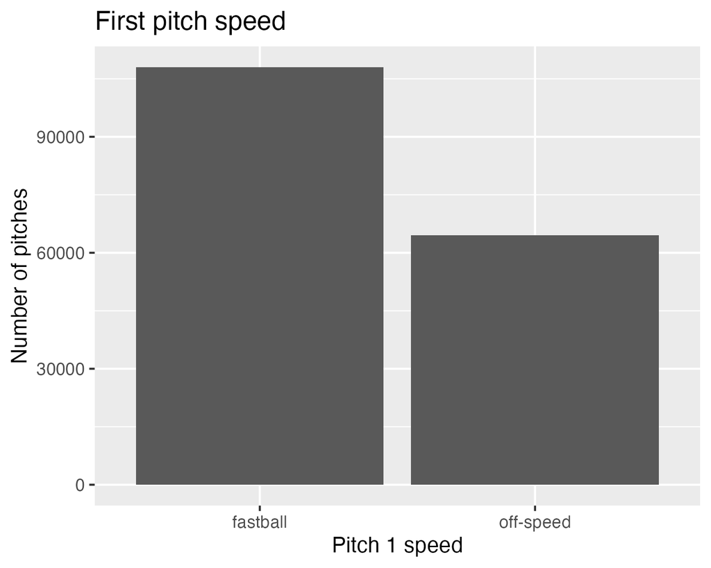

Figure 14: Pitch 1 speed

In Figure 14, we see that the majority of first pitches were fastballs. Pitchers like to start out strong. However, they also appreciate an off-speed first pitch, which accounts for over one-third of the plate appearances. Perhaps more interesting: assuming there is one, what happens on the second pitch? Figure 15 attempts to answer that.

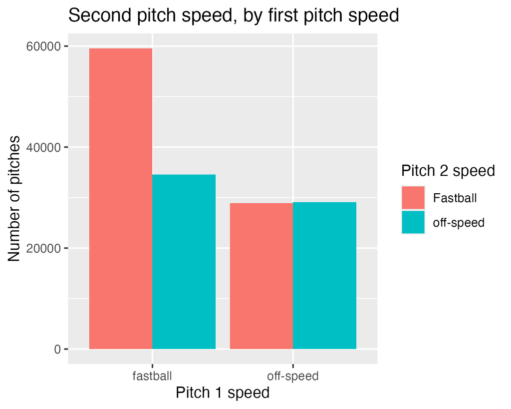

Figure 15: Pitch 2 by Pitch 1

If the first pitch was a fastball, it’s likely (but not at all certain) that the second one will be too. Fastball-fastball was by far the most popular pitch 1-pitch 2 combination in the data. If pitch 1 was off-speed however, there’s a slightly-greater-than-50% chance the second one will be off-speed as well. Psychologically, that makes some sense. A batter isn’t expecting a first-pitch off-speed pitch, so once it comes, they’ll assume the pitcher will try to counter with something strong. Thus, the best move is to throw another off-speed and catch them off guard.

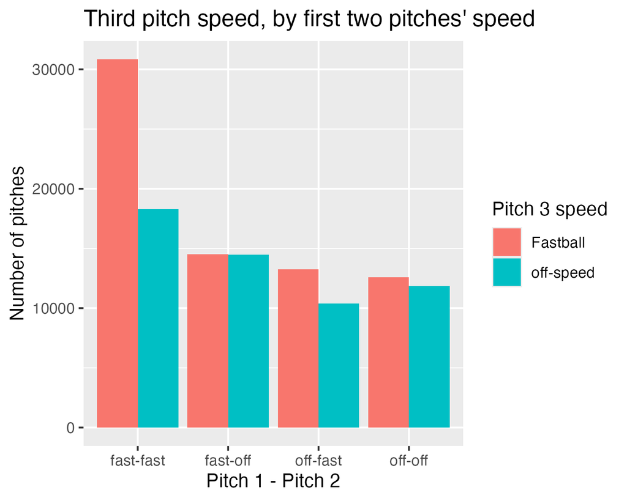

Figure 16: Pitch 3 by Pitches 1 and 2

Table 4: Pitch 2 by Pitch 1 outcome

[figure not shown]

#### Speed and Batter Interaction

We’ve talked about pitching strategy and the way speed affects future pitches. Now, we turn to the hitter. Newton’s Third Law states that for every action, there is an opposite and equal reaction. We can apply this to hitting a baseball. In order to hit a baseball hard and fast, one must receive a pitch with enough force. Therefore, we might suspect that the speed of a pitch influences the resulting launch speed of the batted ball.

In Figure 17, we put this theory to the test. We compare four-seam fastballs (FF) with sliders (SL). These are the two most popular pitches in the dataset. Note that sliders are among the faster off-speed pitches.

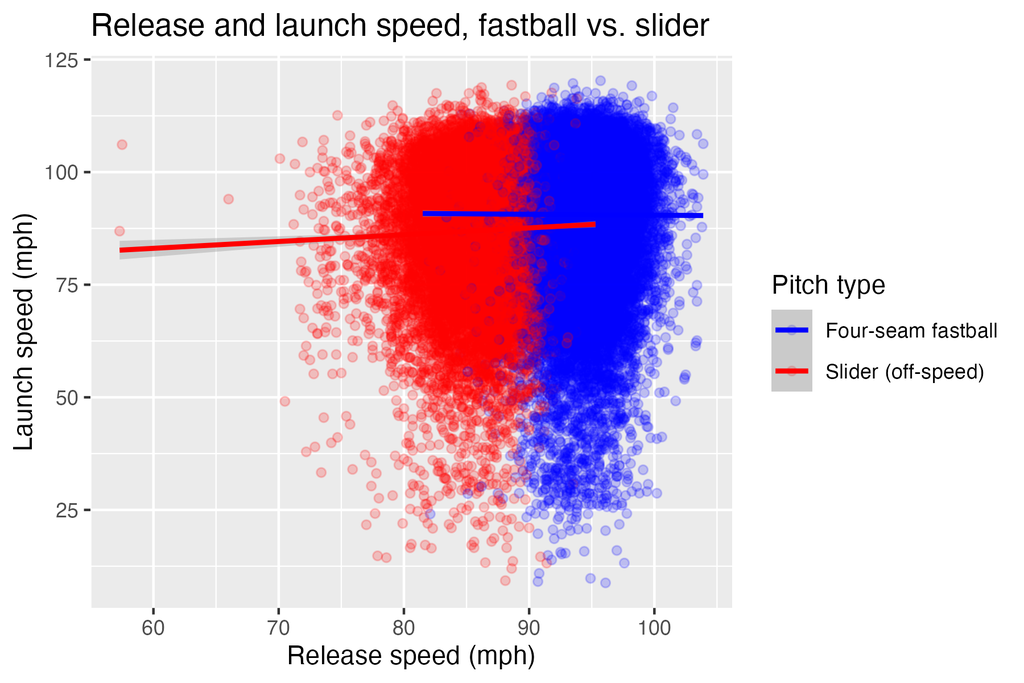

Figure 17: Fastballs vs. sliders

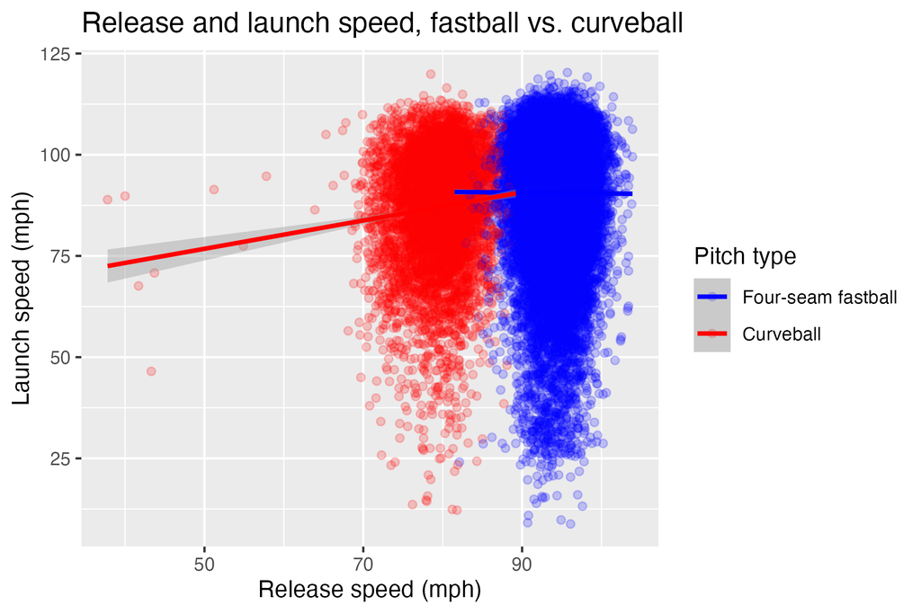

Figure 18: Fastballs vs. curveballs

Curveballs are slower than sliders, allowing them to achieve more movement. And while the curveball has a noticeably lower “peak” to its mass of points, it still produces exit velocities much higher than we’d expect. Note that the line-of-best-fit for the curveball is steeper than that of the slider. The discrepancy between what we imagined the relationship would be and what it actually is could stem from the confounding variables. Spin rate, bat speed, and launch angle are all said to influence launch speed, so its unlikely that we could see as clear a relationship between release speed and launch speed as we’d initially suspected.

Curiously, I calculated the correlations of several potential confounding variables with `launch_speed` and themselves. Then, I used `corrplot()` to make the results easy to interpret in Figure 19. The results were interesting: bat speed had a moderate-to-low strength positive correlation with launch speed, but all of the other confounding variables had little to no correlation.

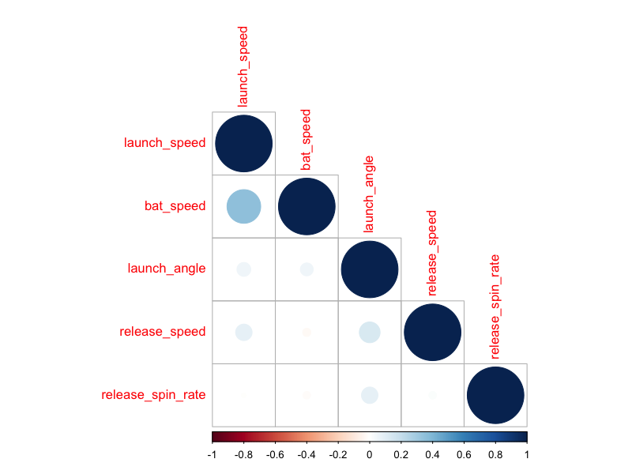

Figure 19: Launch speed correlations